# Session 4: Linking and joining data & SQL

ESS: Introduction to Web Scraping and Data Management for Social Scientists

Johannes B. Gruber

2026-07-23

# Introduction

## This Course

| Day | Session |
| --- | --- |
| 1 | Introduction |
| 2 | Data Structures and Wrangling |
| 3 | Working with Files |
| 4 | Linking and joining data & SQL |
| 5 | Scaling, Reporting and Database Software |
| 6 | Introduction to the Web |
| 7 | Static Web Pages |
| 8 | Application Programming Interface (APIs) |
| 9 | Interactive Web Pages |
| 10 | Building a Reproducible Research Project |

## The Plan for Today

In this session, you learn:

- why and how to work with relational data
- how to join data from different tables in `R`
- how to join data from different tables in `SQL`

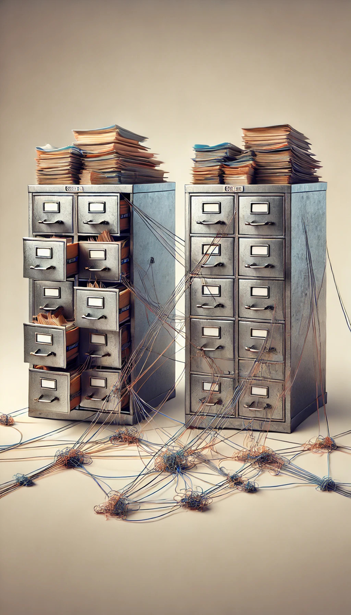

Via DALL-E

# Relational data

## Why do we need to join data?

- It’s rare that a data analysis involves only a single data frame
- As we learned in session 2: good tables don’t contain redundancies (information about different entities should be stored separately)
- Most databases use a relational database management system (or RDBMS)
- Practically, we always think of relations as a connection of two tables
- Relations of three or more tables are always a property of the relations between each pair

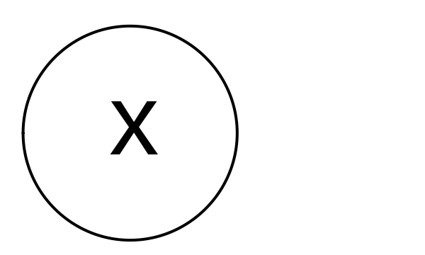

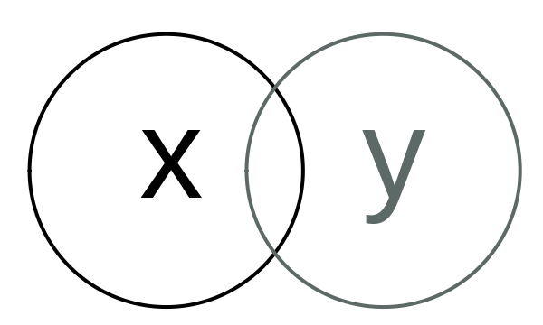

## Basic concept: keys

- **primary key**: a variable or set of variables (which is then called a **composite key**) that uniquely identifies each observation
- **foreign key**: a variable (or set of variables) that refers to a primary key in another table

```r
df1 <- tibble(
  id = 1:6,
  capital_letters = LETTERS[1:6]
)
df1
```

```
# A tibble: 6 × 2
     id capital_letters
  <int> <chr>
1     1 A
2     2 B
3     3 C
4     4 D
5     5 E
6     6 F
```

```r
df2 <- tibble(
  id = c(1:5, 7),
  lowercase_letters = letters[c(1:5, 7)]
)
df2
```

```
# A tibble: 6 × 2
     id lowercase_letters
  <dbl> <chr>
1     1 a
2     2 b
3     3 c
4     4 d
5     5 e
6     7 g
```

# Joining tables in `R`

Source: Wickham et al. (2023)

## Two different joins

- **Mutating joins**: add new variables to one data frame from matching observations in another.
- **Filtering joins**: filter observations from one data frame based on whether or not they match an observation in another.

## left_join

- Mutating join
- keeps all variables from x and y
- keeps all rows from x
- drops rows from y where key has no match in x

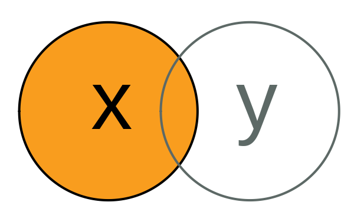

## right_join

- Mutating join
- keeps all variables from x and y
- keeps all rows from y
- drops rows from x where key has no match in y
- if you would reverse x and y, it’s the same as `left_join`

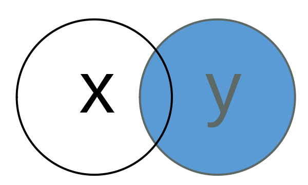

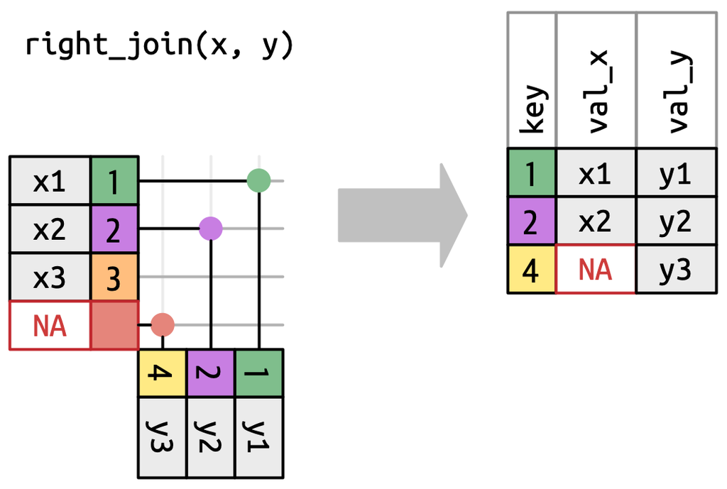

## full_join

- Mutating join
- keeps all variables from x and y
- keeps all rows from x and y

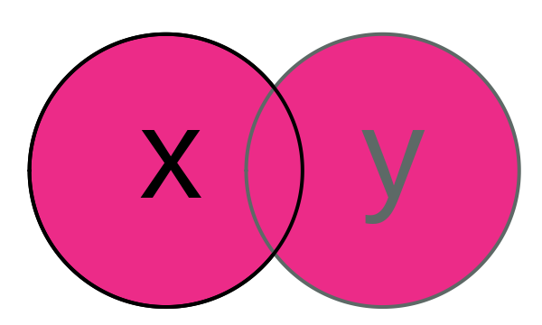

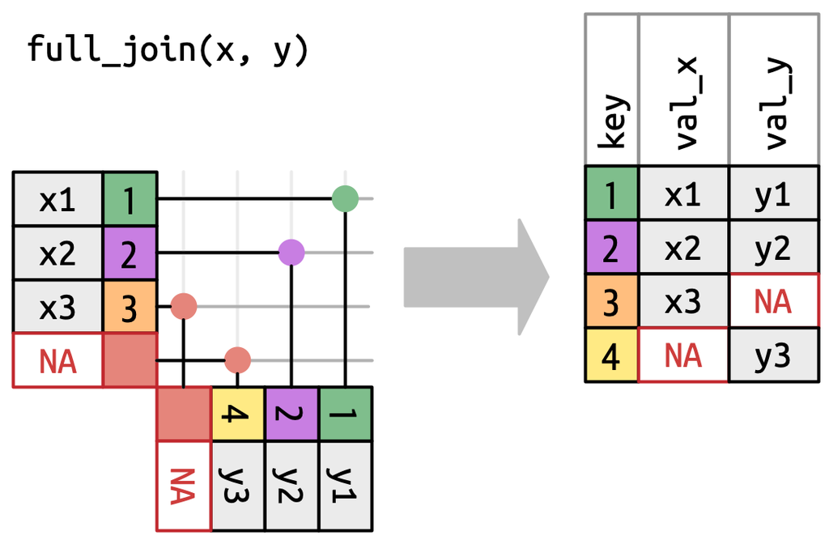

## inner_join

- Mutating join
- keeps all variables from x and y
- drops rows from x where key has no match in y
- drops rows from y where key has no match in x
- essentially only keeps complete cases

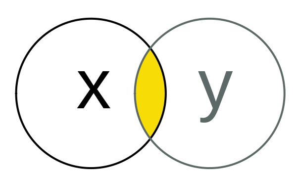

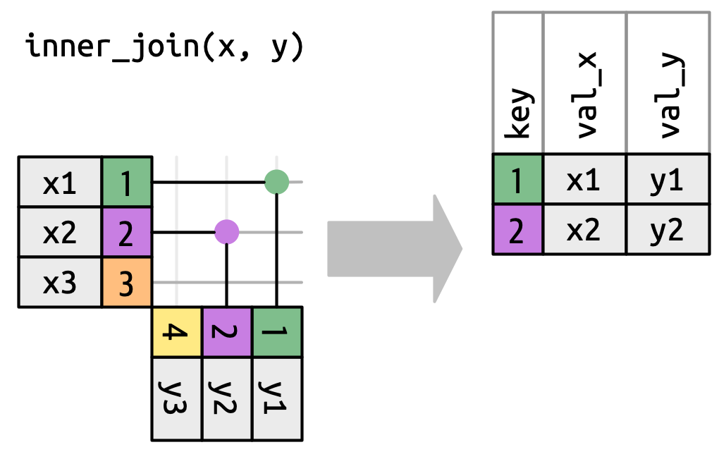

## semi_join

- Filtering join
- only keeps variables from x
- drops rows from x where key has **no** match in y

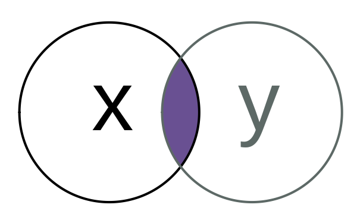

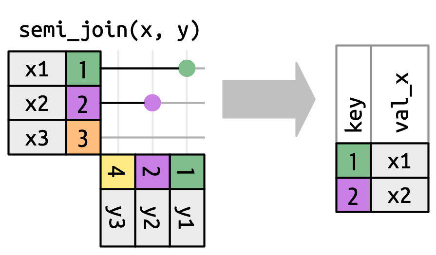

## anti_join

- Filtering join
- only keeps variables from x
- drops rows from x where key has **a** match in y

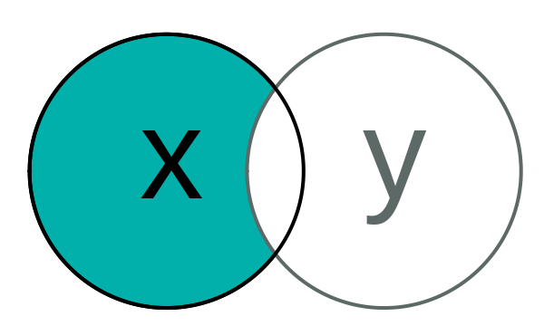

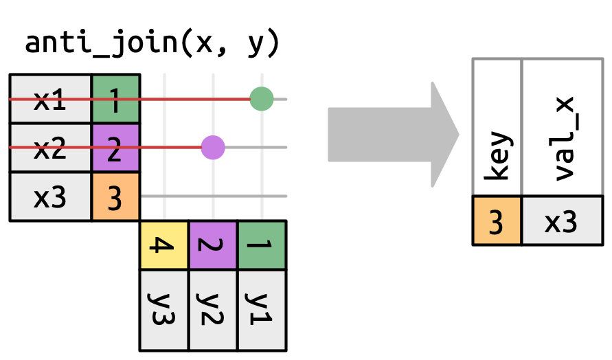

## Syntax: left and right

```r
left_join(df1, df2, by = "id")
```

```
# A tibble: 6 × 3
     id capital_letters lowercase_letters
  <dbl> <chr>           <chr>
1     1 A               a
2     2 B               b
3     3 C               c
4     4 D               d
5     5 E               e
6     6 F               <NA>
```

```r
right_join(df1, df2, by = "id")
```

```
# A tibble: 6 × 3
     id capital_letters lowercase_letters
  <dbl> <chr>           <chr>
1     1 A               a
2     2 B               b
3     3 C               c
4     4 D               d
5     5 E               e
6     7 <NA>            g
```

## Syntax: full and inner join

```r
full_join(df1, df2, by = "id")
```

```
# A tibble: 7 × 3
     id capital_letters lowercase_letters
  <dbl> <chr>           <chr>
1     1 A               a
2     2 B               b
3     3 C               c
4     4 D               d
5     5 E               e
6     6 F               <NA>
7     7 <NA>            g
```

```r
inner_join(df1, df2, by = "id")
```

```
# A tibble: 5 × 3
     id capital_letters lowercase_letters
  <dbl> <chr>           <chr>
1     1 A               a
2     2 B               b
3     3 C               c
4     4 D               d
5     5 E               e
```

## Syntax: semi and anti join

```r
semi_join(df1, df2, by = "id")
```

```
# A tibble: 5 × 2
     id capital_letters
  <int> <chr>
1     1 A
2     2 B
3     3 C
4     4 D
5     5 E
```

Same as:

```r
df1 |>
  filter(id %in% df2$id)
```

```
# A tibble: 5 × 2
     id capital_letters
  <int> <chr>
1     1 A
2     2 B
3     3 C
4     4 D
5     5 E
```

```r
anti_join(df1, df2, by = "id")
```

```
# A tibble: 1 × 2
     id capital_letters
  <int> <chr>
1     6 F
```

```r
df1 |>
  filter(!id %in% df2$id)
```

```
# A tibble: 1 × 2
     id capital_letters
  <int> <chr>
1     6 F
```

## Finding keys

```r
pets <- tribble(
  ~animal  , ~name            , ~breed               ,
  #-----
  "cat"    , "Leo"            , "European Shorthair" ,
  "dog"    , "Bruno"          , "Labrador"           ,
  "cat"    , "Charlie"        , "Ragdolls"           ,
  "mouse"  , "Julius Cheeser" , "Agouti"             ,
  "cat"    , "Felix"          , "Persian"            ,
  "horse"  , "Tina"           , "Mustang"            ,
  "rabbit" , "snowball"       , "Persian"            ,
)
```

```r
breeds <- tribble(
  ~species , ~breed               , ~life_expectancy ,
  #-----
  "cat"    , "European Shorthair" ,               14 ,
  "dog"    , "Labrador"           ,               11 ,
  "cat"    , "Ragdolls"           ,               15 ,
  "cat"    , "Persian"            ,               15 ,
  "mouse"  , "Agouti"             ,                1 ,
  "snake"  , "Python"             ,               25 ,
  "rabbit" , "Persian"            ,               12 ,
)
```

Two criteria:

- primary key should uniquely identify cases
- primary key should have a corresponding foreign key (at least for some cases)

## Finding keys

```r
left_join(pets, breeds, by = c("animal" = "species"), suffix = c("_x", "_y"))
```

```
# A tibble: 13 × 5
   animal name           breed_x            breed_y            life_expectancy
   <chr>  <chr>          <chr>              <chr>                        <dbl>
 1 cat    Leo            European Shorthair European Shorthair              14
 2 cat    Leo            European Shorthair Ragdolls                        15
 3 cat    Leo            European Shorthair Persian                         15
 4 dog    Bruno          Labrador           Labrador                        11
 5 cat    Charlie        Ragdolls           European Shorthair              14
 6 cat    Charlie        Ragdolls           Ragdolls                        15
 7 cat    Charlie        Ragdolls           Persian                         15
 8 mouse  Julius Cheeser Agouti             Agouti                           1
 9 cat    Felix          Persian            European Shorthair              14
10 cat    Felix          Persian            Ragdolls                        15
11 cat    Felix          Persian            Persian                         15
12 horse  Tina           Mustang            <NA>                            NA
13 rabbit snowball       Persian            Persian                         12
```

```r
left_join(pets, breeds, by = c("animal" = "species", "breed"))
```

```
# A tibble: 7 × 4
  animal name           breed              life_expectancy
  <chr>  <chr>          <chr>                        <dbl>
1 cat    Leo            European Shorthair              14
2 dog    Bruno          Labrador                        11
3 cat    Charlie        Ragdolls                        15
4 mouse  Julius Cheeser Agouti                           1
5 cat    Felix          Persian                         15
6 horse  Tina           Mustang                         NA
7 rabbit snowball       Persian                         12
```

```r
right_join(pets, breeds, by = c("animal" = "species", "breed"))
```

```
# A tibble: 7 × 4
  animal name           breed              life_expectancy
  <chr>  <chr>          <chr>                        <dbl>
1 cat    Leo            European Shorthair              14
2 dog    Bruno          Labrador                        11
3 cat    Charlie        Ragdolls                        15
4 mouse  Julius Cheeser Agouti                           1
5 cat    Felix          Persian                         15
6 rabbit snowball       Persian                         12
7 snake  <NA>           Python                          25
```

## Finding keys

```r
full_join(pets, breeds, by = c("animal" = "species", "breed"))
```

```
# A tibble: 8 × 4
  animal name           breed              life_expectancy
  <chr>  <chr>          <chr>                        <dbl>
1 cat    Leo            European Shorthair              14
2 dog    Bruno          Labrador                        11
3 cat    Charlie        Ragdolls                        15
4 mouse  Julius Cheeser Agouti                           1
5 cat    Felix          Persian                         15
6 horse  Tina           Mustang                         NA
7 rabbit snowball       Persian                         12
8 snake  <NA>           Python                          25
```

```r
inner_join(pets, breeds, by = c("animal" = "species", "breed"))
```

```
# A tibble: 6 × 4
  animal name           breed              life_expectancy
  <chr>  <chr>          <chr>                        <dbl>
1 cat    Leo            European Shorthair              14
2 dog    Bruno          Labrador                        11
3 cat    Charlie        Ragdolls                        15
4 mouse  Julius Cheeser Agouti                           1
5 cat    Felix          Persian                         15
6 rabbit snowball       Persian                         12
```

## Finding keys

```r
semi_join(pets, breeds, by = c("animal" = "species", "breed"))
```

```
# A tibble: 6 × 3
  animal name           breed
  <chr>  <chr>          <chr>
1 cat    Leo            European Shorthair
2 dog    Bruno          Labrador
3 cat    Charlie        Ragdolls
4 mouse  Julius Cheeser Agouti
5 cat    Felix          Persian
6 rabbit snowball       Persian
```

```r
anti_join(pets, breeds, by = c("animal" = "species", "breed"))
```

```
# A tibble: 1 × 3
  animal name  breed
  <chr>  <chr> <chr>
1 horse  Tina  Mustang
```

```r
pets |>
  filter(animal %in% breeds$species, breed %in% breeds$breed)
```

```
# A tibble: 6 × 3
  animal name           breed
  <chr>  <chr>          <chr>
1 cat    Leo            European Shorthair
2 dog    Bruno          Labrador
3 cat    Charlie        Ragdolls
4 mouse  Julius Cheeser Agouti
5 cat    Felix          Persian
6 rabbit snowball       Persian
```

```r
pets |>
  filter(!animal %in% breeds$species, !breed %in% breeds$breed)
```

```
# A tibble: 1 × 3
  animal name  breed
  <chr>  <chr> <chr>
1 horse  Tina  Mustang
```

## Many to many

- When you get a many-to-many instead of a many-to-one join, it can indicate a problem
- Either you have chosen the wrong key by accident or your data model is wrong
- But the question is a conceptual one:
  - For example, several pets usually have the same species and breed, but one pet should have one breed (or maybe a mix)
  - But a single pet can have multiple owners, and each owner can have multiple pets
- So ask yourself: is it plausible that one obesrvation in table A relates to several in B

### many-to-one

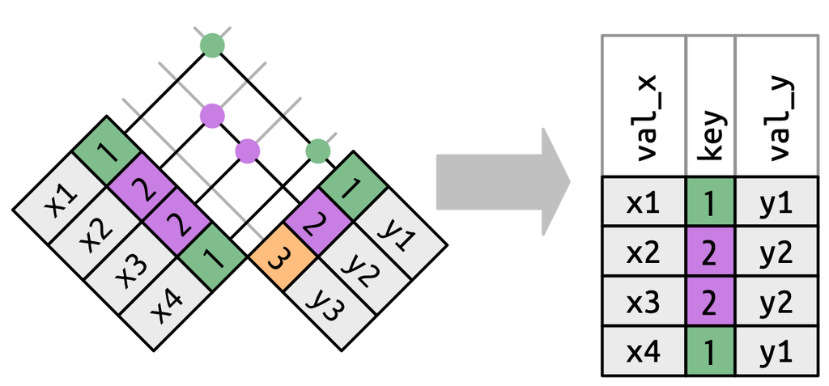

### many-to-many

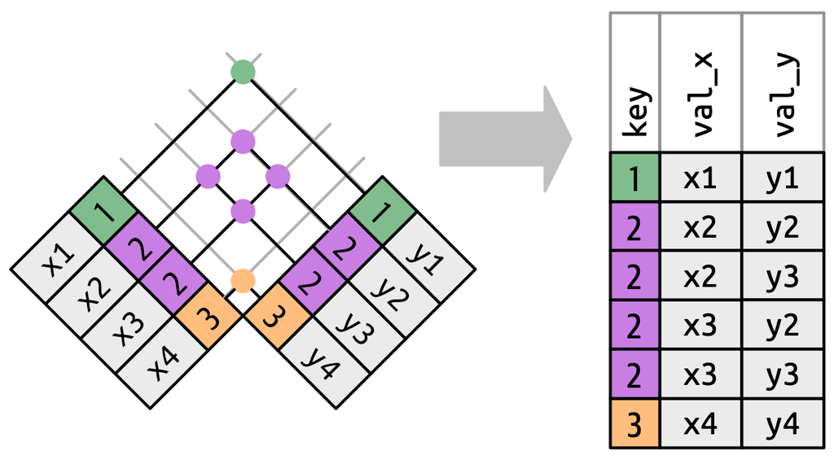

## Case study: 2016 US primaries

```r
library(rio)
csv_folder_url <- "https://raw.githubusercontent.com/houstondatavis/data-jam-august-2016/master/csv"
results <- import(paste(csv_folder_url, "primary_results.csv", sep = "/"))
schedule <- import(paste(csv_folder_url, "primary_schedule.csv", sep = "/"))
facts <- import(paste(csv_folder_url, "county_facts.csv", sep = "/")) |>
  select(
    area_name,
    population = Pop_2014_count,
    pop_change = Pop_change_pct,
    over65 = Age_over_65_pct,
    female = Sex_female_pct,
    white = Race_white_pct,
    college = Pop_college_grad_pct,
    income = Income_per_capita
  )
```

```r
glimpse(results, width = 50)
```

```
Rows: 24,611
Columns: 8
$ state              <chr> "Alabama", "Alabama",…
$ state_abbreviation <chr> "AL", "AL", "AL", "AL…
$ county             <chr> "Autauga", "Autauga",…
$ fips               <dbl> 1001, 1001, 1003, 100…
$ party              <chr> "Democrat", "Democrat…
$ candidate          <chr> "Bernie Sanders", "Hi…
$ votes              <int> 544, 2387, 2694, 5290…
$ fraction_votes     <dbl> 0.182, 0.800, 0.329, …
```

```r
glimpse(schedule, width = 50)
```

```
Rows: 113
Columns: 4
$ date  <chr> "2/1/16", "2/9/16", "2/20/16", "2/…
$ state <chr> "Iowa", "New Hampshire", "Nevada",…
$ party <chr> "Democrat", "Democrat", "Democrat"…
$ type  <chr> "Semi-open caucus", "Semi-closed p…
```

```r
glimpse(facts, width = 50)
```

```
Rows: 3,195
Columns: 8
$ area_name  <chr> "United States", "Alabama", "…
$ population <int> 318857056, 4849377, 55395, 20…
$ pop_change <dbl> 3.3, 1.4, 1.5, 9.8, -2.1, -1.…
$ over65     <dbl> 14.5, 15.3, 13.8, 18.7, 16.5,…
$ female     <dbl> 50.8, 51.5, 51.4, 51.2, 46.6,…
$ white      <dbl> 77.4, 69.7, 77.9, 87.1, 50.2,…
$ college    <dbl> 28.8, 22.6, 20.9, 27.7, 13.4,…
$ income     <int> 28155, 23680, 24571, 26766, 1…
```

- RQ 1: How was each candidate doing at specific points in time?
- RQ 2: Was there a connection between age and candidate preference in the Democratic Party?

## 2016 US primaries: data wrangling

Convert the date in the schedule to date class:

```r
schedule <- schedule |>
  mutate(date = lubridate::mdy(date))
schedule
```

```
          date                state      party                type
1   2016-02-01                 Iowa   Democrat    Semi-open caucus
2   2016-02-09        New Hampshire   Democrat Semi-closed primary
3   2016-02-20               Nevada   Democrat       Closed caucus
4   2016-02-27       South Carolina   Democrat        Open primary
5   2016-03-01              Alabama   Democrat        Open primary
6   2016-03-01       American Samoa   Democrat       Closed caucus
7   2016-03-01             Arkansas   Democrat        Open primary
8   2016-03-01             Colorado   Democrat       Closed caucus
9   2016-03-01              Georgia   Democrat        Open primary
10  2016-03-01        Massachusetts   Democrat Semi-closed primary
11  2016-03-01            Minnesota   Democrat         Open caucus
12  2016-03-01             Oklahoma   Democrat Semi-closed primary
13  2016-03-01            Tennessee   Democrat        Open primary
14  2016-03-01                Texas   Democrat        Open primary
```

[output cut: 99 more lines]

Aggregate results on the state level instead of the county level:

```r
results_state <- results |>
  group_by(state, party, candidate) |>
  summarize(votes = sum(votes))
results_state
```

```
# A tibble: 290 × 4
# Groups:   state, party [95]
   state   party      candidate        votes
   <chr>   <chr>      <chr>            <int>
 1 Alabama Democrat   Bernie Sanders   76399
 2 Alabama Democrat   Hillary Clinton 309928
 3 Alabama Republican Ben Carson       87517
 4 Alabama Republican Donald Trump    371735
 5 Alabama Republican John Kasich      37970
 6 Alabama Republican Marco Rubio     159802
 7 Alabama Republican Ted Cruz        180608
 8 Alaska  Democrat   Bernie Sanders     440
 9 Alaska  Democrat   Hillary Clinton     99
10 Alaska  Republican Ben Carson        2401
# ℹ 280 more rows
```

## 2016 US primaries: candidates performance over time

```r
results_state_time <- results_state |>
  inner_join(schedule, by = c("state", "party"))
results_state_time
```

```
# A tibble: 290 × 6
# Groups:   state, party [95]
   state   party      candidate        votes date       type
   <chr>   <chr>      <chr>            <int> <date>     <chr>
 1 Alabama Democrat   Bernie Sanders   76399 2016-03-01 Open primary
 2 Alabama Democrat   Hillary Clinton 309928 2016-03-01 Open primary
 3 Alabama Republican Ben Carson       87517 2016-03-01 Open primary
 4 Alabama Republican Donald Trump    371735 2016-03-01 Open primary
 5 Alabama Republican John Kasich      37970 2016-03-01 Open primary
 6 Alabama Republican Marco Rubio     159802 2016-03-01 Open primary
 7 Alabama Republican Ted Cruz        180608 2016-03-01 Open primary
 8 Alaska  Democrat   Bernie Sanders     440 2016-03-26 Closed caucus
 9 Alaska  Democrat   Hillary Clinton     99 2016-03-26 Closed caucus
10 Alaska  Republican Ben Carson        2401 2016-03-01 Closed caucus
# ℹ 280 more rows
```

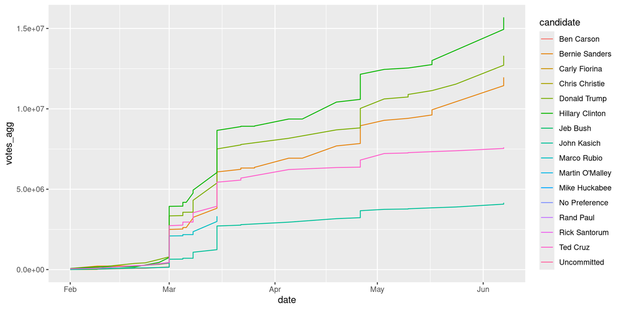

```r
results_state_time |>
  arrange(date) |>
  group_by(candidate) |>
  mutate(votes_agg = cumsum(votes)) |>
  ungroup() |>
  ggplot(mapping = aes(x = date, y = votes_agg, colour = candidate)) +
  geom_line()
```

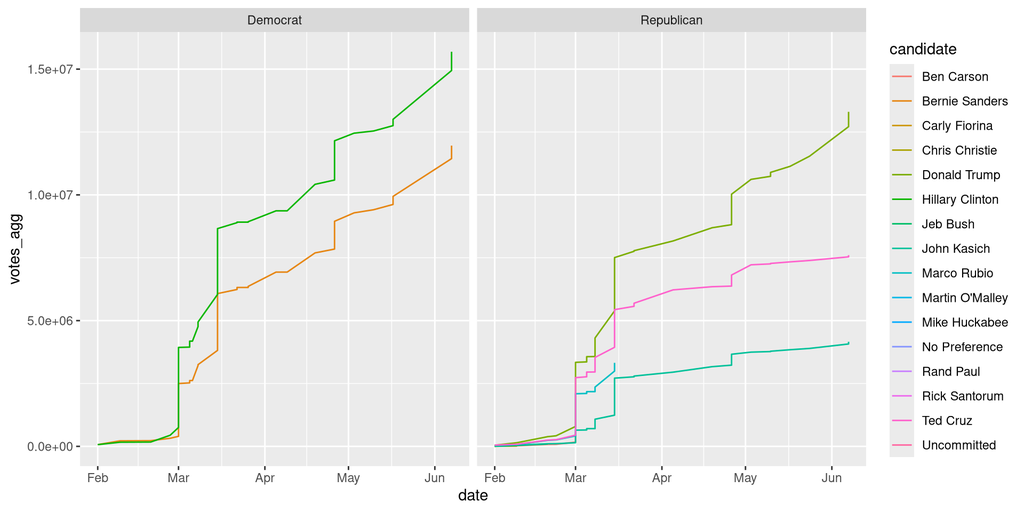

```r
results_state_time |>
  arrange(date) |>
  group_by(candidate) |>
  mutate(votes_agg = cumsum(votes)) |>
  ungroup() |>
  ggplot(mapping = aes(x = date, y = votes_agg, colour = candidate)) +
  geom_line() +
  facet_wrap("party")
```

## 2016 US primaries: candidates performance vs average age

```r
results_state_facts <- results_state |>
  inner_join(facts, by = c("state" = "area_name")) |>
  group_by(state, party) |>
  mutate(total_votes = sum(votes), pct_votes = votes / total_votes) |>
  ungroup()
results_state_facts
```

```
# A tibble: 290 × 13
   state   party      candidate  votes population pop_change over65 female white
   <chr>   <chr>      <chr>      <int>      <int>      <dbl>  <dbl>  <dbl> <dbl>
 1 Alabama Democrat   Bernie S…  76399    4849377        1.4   15.3   51.5  69.7
 2 Alabama Democrat   Hillary … 309928    4849377        1.4   15.3   51.5  69.7
 3 Alabama Republican Ben Cars…  87517    4849377        1.4   15.3   51.5  69.7
 4 Alabama Republican Donald T… 371735    4849377        1.4   15.3   51.5  69.7
 5 Alabama Republican John Kas…  37970    4849377        1.4   15.3   51.5  69.7
 6 Alabama Republican Marco Ru… 159802    4849377        1.4   15.3   51.5  69.7
 7 Alabama Republican Ted Cruz  180608    4849377        1.4   15.3   51.5  69.7
 8 Alaska  Democrat   Bernie S…    440     736732        3.7    9.4   47.4  66.9
 9 Alaska  Democrat   Hillary …     99     736732        3.7    9.4   47.4  66.9
10 Alaska  Republican Ben Cars…   2401     736732        3.7    9.4   47.4  66.9
# ℹ 280 more rows
# ℹ 4 more variables: college <dbl>, income <int>, total_votes <int>,
#   pct_votes <dbl>
```

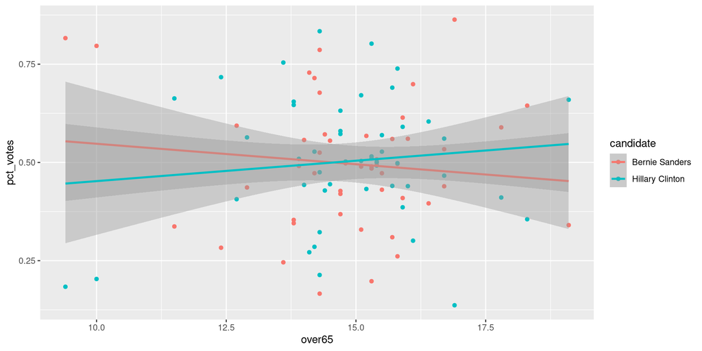

```r
results_state_facts |>
  filter(
    party == "Democrat",
    candidate %in% c("Bernie Sanders", "Hillary Clinton")
  ) |>
  ggplot(aes(x = over65, y = pct_votes, colour = candidate)) +
  geom_point() +
  geom_smooth(method = "lm", formula = y ~ x)
```

## Exercises 1

1. See if some of the other variables influence support for Sanders or Clinton
2. Below I prepared code that loads data from the `nycflights13` package which is about flights departing NYC in 2013:

```r
library(nycflights13)
data(airports)
data(flights)
data(weather)
data(planes)
data(airlines)
```

Imagine you wanted to draw (approximately) the route each plane flies from its origin to its destination. What variables would you need? What data frames would you need to combine?

3. Add the location of the origin *and* destination (i.e. the `lat` and `lon`) to `flights`.
4. Which airlines departed most often from the NYC airports (i.e. JFK, LGA or EWR). Use their real names not the abbreviation
5. How could you calculate the average age of the planes departing from NYC? (hint: you can calculate averages with `mean()`, you might want to use `na.rm = TRUE`)

# Intro to *Structured query language* (`SQL`)

## Why learn `SQL`?

- managing tables in files instead of a database is error-prone:
  - you need to keep files consistent
  - you need to maintain relational integrity
- using files instead of a database is slow:
  - you have to read in files before doing operations on the data (although systems like `arrow` improve the situation)
  - you need to use your local hardware instead of a remote server (although you could SSH into a server)
  - collaboration is limited and again error-prone
- database management system (DBMS), which solve these issues often speak `Structured Query Language` (`SQL`)

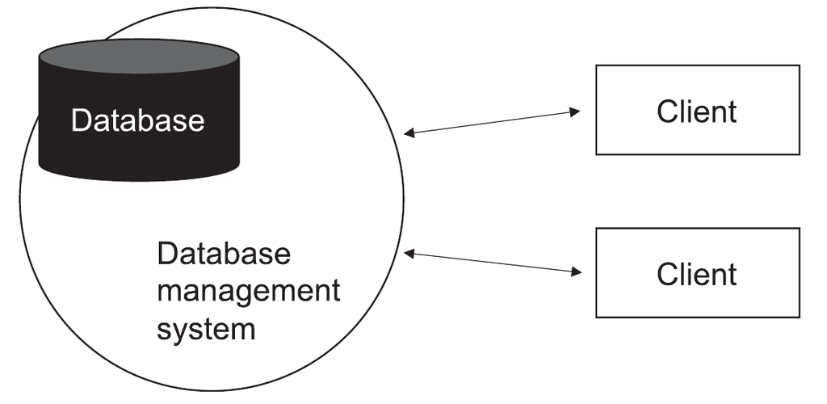

Interacting with a database management system from Weidmann (2023), p. 105.

## `SQL` basic syntax

- `R` has a generic interface to communicate with relational databases: *R Database Interface* or `DBI`

```r
library(DBI)
```

To communicate with a specific database format, `DBI` needs a driver

```r
library(RSQLite)
```

- **RSQLite**: translates `R` commands to *SQLite*
- **SQLite**: a free and open source, well-known embedded database engine

## Creating and connecting to an SQLite database

```r
dir.create("data", showWarnings = FALSE)
unlink("data/db.sql") # just to make sure we use a new db
db <- dbConnect(SQLite(), "data/db.sql")
db
```

```
<SQLiteConnection>
  Path: data/db.sql
  Extensions: TRUE
```

```r
class(db)
```

```
[1] "SQLiteConnection"
attr(,"package")
[1] "RSQLite"
```

- **dbConnect()**: sets up a connection
- **SQLite()**: provides the driver for the specific DBMS

Let’s see what’s in the database so far:

```r
dbGetQuery(db, "SELECT name FROM sqlite_master")
```

```
[1] name
<0 rows> (or 0-length row.names)
```

Nothing. SQLite databases are typically stored in a single file:

```r
file.size("data/db.sql")
```

```
[1] 0
```

Our file has the size 0, which means it consists just of a place-holder.

## Adding a table to the SQLite database

So far, the database is empty:

```r
# this is a shorthand for "SELECT name FROM sqlite_master" above
dbListTables(db)
```

```
character(0)
```

Before we can add data, we have to create a table in the database:

```r
dbExecute(
  db,
  "CREATE TABLE df1 (
            election_id integer,
            capital_letters varchar)"
)
```

```
[1] 0
```

```r
dbListTables(db)
```

```
[1] "df1"
```

Besides integer and varchar (suitable for short strings), you can also use `real` (numeric), dates and blob (stored as binary data).

Now we can add cases:

```r
dbExecute(
  db,
  "INSERT INTO df1
            VALUES (1, 'A')"
)
```

```
[1] 1
```

And we can pull the data back out:

```r
dbGetQuery(db, "SELECT * FROM df1")
```

```
  election_id capital_letters
1           1               A
```

We can start from scratch by deleting this table:

```r
dbExecute(db, "DROP TABLE df1")
```

```
[1] 0
```

## Adding a table with constraints

We dropped the last table, so the database is empty again

```r
dbListTables(db)
```

```
character(0)
```

Let’s define the table again, but add constraints to enforce certain data:

```r
dbExecute(
  db,
  "CREATE TABLE df1 (
              id INTEGER PRIMARY KEY,
              capital_letters VARCHAR(1) CHECK (capital_letters GLOB '[A-Z]'),
              my_date DATE CHECK (my_date > '2000-01-01')
          )"
)
```

```
[1] 0
```

```r
dbListTables(db)
```

```
[1] "df1"
```

- `id` is now a primary key, which makes sure that it is unique
- the field `capital_letters` is now constrained to capital letters
- only dates in 2000 or later are allowed

## Adding a table with constraints

Let’s try to add a case:

```r
dbExecute(
  db,
  "INSERT INTO df1
            VALUES (1, 'a', '1999-12-31')"
)
```

```
Error:
! CHECK constraint failed: capital_letters GLOB '[A-Z]'
```

Let’s try again with a capital letter:

```r
dbExecute(
  db,
  "INSERT INTO df1
            VALUES (1, 'A', '1999-12-31')"
)
```

```
Error:
! CHECK constraint failed: my_date > '2000-01-01'
```

OK, let’s adhere to the constraints:

```r
dbExecute(
  db,
  "INSERT INTO df1
            VALUES (1, 'A', '2000-12-31')"
)
```

```
[1] 1
```

And let’s test the last constraint:

```r
dbExecute(
  db,
  "INSERT INTO df1
            VALUES (1, 'A', '2000-12-31')"
)
```

```
Error:
! UNIQUE constraint failed: df1.id
```

## Adding Data

We already know how to add a complete case:

```r
dbExecute(
  db,
  "INSERT INTO df1
            VALUES (2, 'B', '2000-12-31')"
)
```

```
[1] 1
```

But you can also add a case with a missing value:

```r
dbExecute(
  db,
  "INSERT INTO df1 (id, capital_letters)
            VALUES (3, 'C')"
)
```

```
[1] 1
```

OR:

```r
dbExecute(
  db,
  "INSERT INTO df1
            VALUES (4, 'D', NULL)"
)
```

```
[1] 1
```

```r
dbGetQuery(db, "SELECT * FROM df1")
```

```
  id capital_letters    my_date
1  1               A 2000-12-31
2  2               B 2000-12-31
3  3               C       <NA>
4  4               D       <NA>
```

## Updating Data

If we made a mistake or something changes, we can update a specific row:

```r
dbExecute(
  db,
  "UPDATE df1
               SET my_date = '2023-07-22'
               WHERE id = 3"
)
```

```
[1] 1
```

Or we can add a new variable and calculate it from existing values:

```r
dbExecute(db, "ALTER TABLE df1 ADD year integer")
```

```
[1] 0
```

```r
dbExecute(
  db,
  "UPDATE df1
               SET year = strftime('%Y', my_date)"
)
```

```
[1] 4
```

```r
dbGetQuery(db, "SELECT * FROM df1")
```

```
  id capital_letters    my_date year
1  1               A 2000-12-31 2000
2  2               B 2000-12-31 2000
3  3               C 2023-07-22 2023
4  4               D       <NA>   NA
```

## Accessing Data

We have already seen the `SELECT` command, let’s explore what else we can do!

Access only certain fields:

```r
dbGetQuery(db, "SELECT id, year FROM df1")
```

```
  id year
1  1 2000
2  2 2000
3  3 2023
4  4   NA
```

Access only certain rows:

```r
dbGetQuery(
  db,
  "SELECT id, year
                FROM df1
                WHERE year > 2000"
)
```

```
  id year
1  3 2023
```

Computing new values on the fly:

```r
dbGetQuery(db, "SELECT id, my_date, strftime('%d, %m', my_date) FROM df1")
```

```
  id    my_date strftime('%d, %m', my_date)
1  1 2000-12-31                      31, 12
2  2 2000-12-31                      31, 12
3  3 2023-07-22                      22, 07
4  4       <NA>                        <NA>
```

## Deleting Data

Two ways to get rid of data:

- `DELETE`: used to remove rows from a table
- `DROP`: used to remove entire database objects like tables, databases, indexes, or views

```r
dbExecute(
  db,
  "DELETE FROM df1
               WHERE id = 1"
)
```

```
[1] 1
```

```r
dbGetQuery(db, "SELECT * FROM df1")
```

```
  id capital_letters    my_date year
1  2               B 2000-12-31 2000
2  3               C 2023-07-22 2023
3  4               D       <NA>   NA
```

```r
dbExecute(db, "DROP TABLE df1")
```

```
[1] 0
```

```r
dbGetQuery(db, "SELECT * FROM df1")
```

```
Error:
! no such table: df1
```

## `SQL` basic syntax: summary

- insensitive to line breaks
- case-insensitive
- convention to spell SQL keywords in upper case, and names of tables, columns, and functions in lower case
- important verbs are:
  - `CREATE`: define a new table
  - `INSERT`: add new rows to a table
  - `UPDATE`: modify existing rows in a table
  - `ALTER`: modify existing fields in a table
  - `SELECT`: query data from one or more tables
  - `DELETE`: remove rows from a table
  - `DROP`: remove a database object (e.g., table)

```r
dbGetQuery(
  db,
  "SELECT *
                FROM df1
                WHERE id < 4"
)
```

```r
dbGetQuery(db, "sELeCt id FROM Df1 wHEre iD < 4")
```

[figure not shown]

## `SQL` basic syntax (from `R`)

There are a couple of useful functions in the `DBI` package/the driver packages. We’ve seen the `dbListTables` already:

```r
dbListTables(db)
```

```
character(0)
```

You can also create a table from a data.frame:

```r
dbWriteTable(conn = db, name = "df1", value = df1)
dbWriteTable(conn = db, name = "df2", value = df2)
```

And get information about the defined fields (fields is the equivalent of columns):

```r
dbListFields(conn = db, name = "df1")
```

```
[1] "id"              "capital_letters"
```

```r
dbListFields(conn = db, name = "df2")
```

```
[1] "id"                "lowercase_letters"
```

## `SQL` basic syntax (from `R`)

We can read the entire table back into `R`:

```r
dbReadTable(conn = db, "df1")
```

```
  id capital_letters
1  1               A
2  2               B
3  3               C
4  4               D
5  5               E
6  6               F
```

Delete (drop) a table:

```r
dbRemoveTable(conn = db, "df1")
```

Check if a table exists

```r
if (!dbExistsTable(conn = db, "df1")) {
  message("df1 does not exist. Creating it")
  dbWriteTable(conn = db, name = "df1", value = df1)
}
```

## Exercises 2

1. create a new table in `db` called `elections` with the fields: `election_id`, `country_name`, `election_date`, `party_id`, `vote_share`, `seats`, and `seats_total`. Choose appropriate data types for the fields (maybe peak ahead to the next exercise).
2. Using SQL syntax, add this data to the `elections` table:

| election_id | country_name | election_date | party_id | vote_share | seats | seats_total |
| --- | --- | --- | --- | --- | --- | --- |
| 1030 | Austria | 1919-02-16 | 97 | 40.75 | 72 | 170 |

3. Using SQL syntax, add this data to the `elections` table:

| election_id | country_name | election_date | vote_share | party_id |
| --- | --- | --- | --- | --- |
| 872 | Belgium | 1908-05-24 | 22.6 | 2422 |

4. Querying data from `elections`, create an `R` object that has the `election_id`, `party_id` and `vote_share` fields for elections after 1910.
5. Querying data from `elections`, get `election_id`, `party_id`, `vote_share` fields and just the year of the election.
6. Add a new field `vote_share_prop` to the `elections` database which shows the vote share as proportion rather than a percentage.

# Joining tables in `SQL`

## Some good news

We basically already know how joining in SQL works!

[figure not shown]

## `SQL` vs `R`: left_join

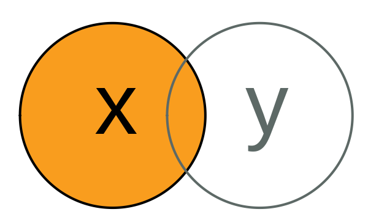

### `R`

```r
left_join(x = df1, y = df2, by = c("id" = "id"))
```

```
# A tibble: 6 × 3
     id capital_letters lowercase_letters
  <dbl> <chr>           <chr>
1     1 A               a
2     2 B               b
3     3 C               c
4     4 D               d
5     5 E               e
6     6 F               <NA>
```

### `SQL`

```r
dbGetQuery(
  db,
  "SELECT * FROM df1
                LEFT JOIN df2
                ON df1.id = df2.id"
)
```

```
  id capital_letters id lowercase_letters
1  1               A  1                 a
2  2               B  2                 b
3  3               C  3                 c
4  4               D  4                 d
5  5               E  5                 e
6  6               F NA              <NA>
```

## right_join

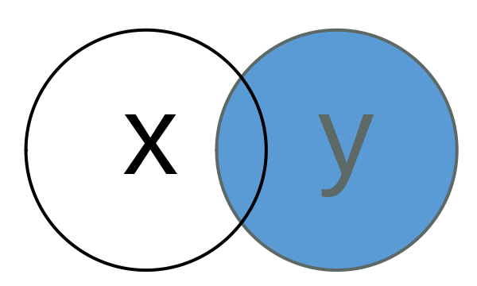

### `R`

```r
right_join(x = df1, y = df2, by = c("id" = "id"))
```

```
# A tibble: 6 × 3
     id capital_letters lowercase_letters
  <dbl> <chr>           <chr>
1     1 A               a
2     2 B               b
3     3 C               c
4     4 D               d
5     5 E               e
6     7 <NA>            g
```

### `SQL`

```r
dbGetQuery(
  db,
  "SELECT * FROM df1
                RIGHT JOIN df2
                ON df1.id = df2.id"
)
```

```
  id capital_letters id lowercase_letters
1  1               A  1                 a
2  2               B  2                 b
3  3               C  3                 c
4  4               D  4                 d
5  5               E  5                 e
6 NA            <NA>  7                 g
```

## full_join

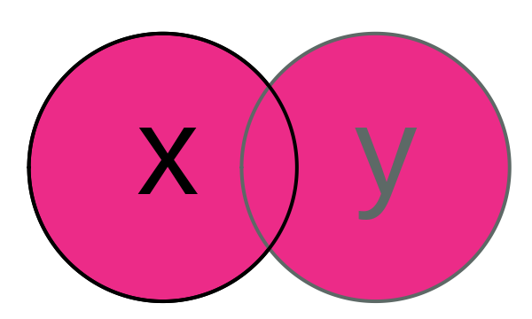

### `R`

```r
full_join(x = df1, y = df2, by = c("id" = "id"))
```

```
# A tibble: 7 × 3
     id capital_letters lowercase_letters
  <dbl> <chr>           <chr>
1     1 A               a
2     2 B               b
3     3 C               c
4     4 D               d
5     5 E               e
6     6 F               <NA>
7     7 <NA>            g
```

### `SQL`

```r
dbGetQuery(
  db,
  "SELECT * FROM df1
                FULL JOIN df2
                ON df1.id = df2.id"
)
```

```
  id capital_letters id lowercase_letters
1  1               A  1                 a
2  2               B  2                 b
3  3               C  3                 c
4  4               D  4                 d
5  5               E  5                 e
6  6               F NA              <NA>
7 NA            <NA>  7                 g
```

## inner_join

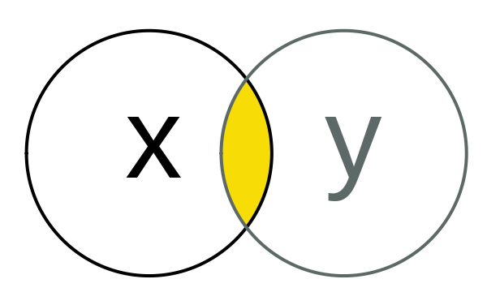

### `R`

```r
inner_join(x = df1, y = df2, by = c("id" = "id"))
```

```
# A tibble: 5 × 3
     id capital_letters lowercase_letters
  <dbl> <chr>           <chr>
1     1 A               a
2     2 B               b
3     3 C               c
4     4 D               d
5     5 E               e
```

### `SQL`

```r
dbGetQuery(
  db,
  "SELECT * FROM df1
                INNER JOIN df2
                ON df1.id = df2.id"
)
```

```
  id capital_letters id lowercase_letters
1  1               A  1                 a
2  2               B  2                 b
3  3               C  3                 c
4  4               D  4                 d
5  5               E  5                 e
```

## semi_join

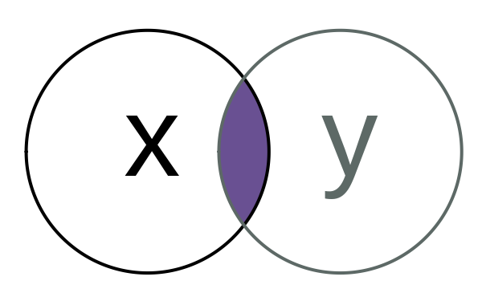

### `R`

```r
semi_join(x = df1, y = df2, by = c("id" = "id"))
```

```
# A tibble: 5 × 2
     id capital_letters
  <int> <chr>
1     1 A
2     2 B
3     3 C
4     4 D
5     5 E
```

```r
df1 |>
  filter(id %in% df2$id)
```

```
# A tibble: 5 × 2
     id capital_letters
  <int> <chr>
1     1 A
2     2 B
3     3 C
4     4 D
5     5 E
```

### `SQL`

```r
dbGetQuery(
  db,
  "SELECT * FROM df1
                WHERE EXISTS (
                  SELECT * FROM df2
                  WHERE df1.id = df2.id
                )"
)
```

```
  id capital_letters
1  1               A
2  2               B
3  3               C
4  4               D
5  5               E
```

## anti_join

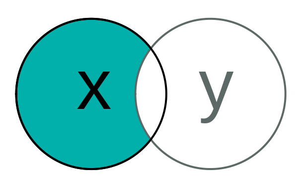

### `R`

```r
anti_join(x = df1, y = df2, by = c("id" = "id"))
```

```
# A tibble: 1 × 2
     id capital_letters
  <int> <chr>
1     6 F
```

```r
df1 |>
  filter(!id %in% df2$id)
```

```
# A tibble: 1 × 2
     id capital_letters
  <int> <chr>
1     6 F
```

### `SQL`

```r
dbGetQuery(
  db,
  "SELECT * FROM df1
                WHERE NOT EXISTS (
                  SELECT 1 FROM df2
                  WHERE df1.id = df2.id
                )"
)
```

```
  id capital_letters
1  6               F
```

## Exercises 3

1. Add the three `data.frames` from the 2016 primaries case study to the database (`schedule`, `results_state`, and `facts`)
2. Right join `results_state` and `facts`
3. Recreate the table `results_state_time` by querying and joining from db. Hint: multiple keys can be used by putting AND between them, e.g., `ON df1.id = df2.id AND df1.id2 = df2.id2`.

# `dbplyr`

## Working with connections in `R`

If you think `SQL` is not necessarily your thing, there is good news: `dbplyr` makes it possible to connect to tables and use `dplyr` syntax. You don’t have to attach `dbplyr` for that, you just need `dplyr` and have `dbplyr` installed.

```r
library(dbplyr) # you don't usually need to load this, just have it installed
```

Let’s create a new table for that:

```r
dbWriteTable(db, "diamonds", diamonds)
```

To connect to a table in a database, we can use `tbl`:

```r
diamonds_con <- tbl(db, "diamonds")
diamonds_con
```

```
# A query:  ?? x 10
# Database: sqlite 3.53.3 [data/db.sql]
   carat cut       color clarity depth table price     x     y     z
   <dbl> <chr>     <chr> <chr>   <dbl> <dbl> <int> <dbl> <dbl> <dbl>
 1  0.23 Ideal     E     SI2      61.5    55   326  3.95  3.98  2.43
 2  0.21 Premium   E     SI1      59.8    61   326  3.89  3.84  2.31
 3  0.23 Good      E     VS1      56.9    65   327  4.05  4.07  2.31
 4  0.29 Premium   I     VS2      62.4    58   334  4.2   4.23  2.63
 5  0.31 Good      J     SI2      63.3    58   335  4.34  4.35  2.75
 6  0.24 Very Good J     VVS2     62.8    57   336  3.94  3.96  2.48
 7  0.24 Very Good I     VVS1     62.3    57   336  3.95  3.98  2.47
 8  0.26 Very Good H     SI1      61.9    55   337  4.07  4.11  2.53
 9  0.22 Fair      E     VS2      65.1    61   337  3.87  3.78  2.49
10  0.23 Very Good H     VS1      59.4    61   338  4     4.05  2.39
# ℹ more rows
```

## Working with connections in `R`

However, this table is just a connection, and `R` has pulled only the first couple of rows to display them.

```r
object.size(diamonds)
```

```
3456848 bytes
```

```r
object.size(diamonds_con)
```

```
8112 bytes
```

This is also why `View` doesn’t really work well:

```r
View(diamonds_con)
```

## `collect`

To get the object in `R` properly, you need to `collect` the data first:

```r
x_df <- collect(diamonds_con)
```

`x_df` is now a real data.frame

```r
object.size(x_df)
```

```
4102608 bytes
```

```r
View(diamonds_con)
```

## Supports `dplyr` verbs

Filter, select, mutate and summarise:

```r
diamonds_con |>
  filter(cut == "Premium", price < 400) |>
  select(price) |>
  mutate(price_gbp = price * 0.77) |>
  summarise(avg_price = mean(price), avg_price_gbp = mean(price_gbp))
```

```
# A query:  ?? x 2
# Database: sqlite 3.53.3 [data/db.sql]
  avg_price avg_price_gbp
      <dbl>         <dbl>
1      376.          289.
```

Joins also work:

```r
df1_con <- tbl(db, "df1")
df2_con <- tbl(db, "df2")
df1_con |>
  left_join(df2_con, by = "id") |>
  collect()
```

```
# A tibble: 6 × 3
     id capital_letters lowercase_letters
  <int> <chr>           <chr>
1     1 A               a
2     2 B               b
3     3 C               c
4     4 D               d
5     5 E               e
6     6 F               <NA>
```

## Supports `dplyr` verbs

```r
df1_con |>
  left_join(df2_con, by = "id") |>
  show_query()
```

```
<SQL>
SELECT `df1`.*, `lowercase_letters`
FROM `df1`
LEFT JOIN `df2`
  ON (`df1`.`id` = `df2`.`id`)
```

## `collect()` vs. `compute()`

- `collect()` gets data from the database; like `dbGetQuery()`
- `compute()` changes data in the database; like `dbExecute()`

We join the two tables again, and also compute a new column:

```r
df1_con |>
  left_join(df2_con, by = "id") |>
  mutate(all_letters = paste(capital_letters, lowercase_letters)) |>
  collect()
```

```
# A tibble: 6 × 4
     id capital_letters lowercase_letters all_letters
  <int> <chr>           <chr>             <chr>
1     1 A               a                 A a
2     2 B               b                 B b
3     3 C               c                 C c
4     4 D               d                 D d
5     5 E               e                 E e
6     6 F               <NA>              <NA>
```

Instead of just bringing this new table to `R`, we can directly save it to the database

```r
df1_con |>
  left_join(df2_con, by = "id") |>
  mutate(all_letters = paste(capital_letters, lowercase_letters)) |>
  compute() # only this line is different!
```

```
# A query:  ?? x 4
# Database: sqlite 3.53.3 [data/db.sql]
     id capital_letters lowercase_letters all_letters
  <int> <chr>           <chr>             <chr>
1     1 A               a                 A a
2     2 B               b                 B b
3     3 C               c                 C c
4     4 D               d                 D d
5     5 E               e                 E e
6     6 F               <NA>              <NA>
```

## `collect()` vs. `compute()`

However, if we look at the table, it still looks the same

```r
df1_con |>
  collect()
```

```
# A tibble: 6 × 2
     id capital_letters
  <int> <chr>
1     1 A
2     2 B
3     3 C
4     4 D
5     5 E
6     6 F
```

So what gives?

## `collect()` vs. `compute()`

When we list the tables, we see what happened:

```r
dbListTables(db)
```

```
[1] "dbplyr_tmp_X2nOSp8Wlq" "df1"                   "df2"
[4] "diamonds"              "sqlite_stat1"          "sqlite_stat4"
```

`dbplyr` by default does not overwrite the original table, but instead saves the results to a new, temporary table (they are removed when you disconnect from the db).

If we want to create a persistent version of the table, we can do:

```r
df1_con |>
  left_join(df2_con, by = "id") |>
  mutate(all_letters = paste(capital_letters, lowercase_letters)) |>
  compute(temporary = FALSE, name = "df1_updated")
```

```
# A query:  ?? x 4
# Database: sqlite 3.53.3 [data/db.sql]
     id capital_letters lowercase_letters all_letters
  <int> <chr>           <chr>             <chr>
1     1 A               a                 A a
2     2 B               b                 B b
3     3 C               c                 C c
4     4 D               d                 D d
5     5 E               e                 E e
6     6 F               <NA>              <NA>
```

```r
tbl(db, "df1_updated")
```

```
# A query:  ?? x 4
# Database: sqlite 3.53.3 [data/db.sql]
     id capital_letters lowercase_letters all_letters
  <int> <chr>           <chr>             <chr>
1     1 A               a                 A a
2     2 B               b                 B b
3     3 C               c                 C c
4     4 D               d                 D d
5     5 E               e                 E e
6     6 F               <NA>              <NA>
```

## `collect()` vs. `compute()`

And finally, if we want to update the table in place, we can bring it into `R` and then copy it back to overwrite the old one:

```r
temp <- df1_con |>
  left_join(df2_con, by = "id") |>
  mutate(all_letters = paste(capital_letters, lowercase_letters)) |>
  collect()
copy_to(db, temp, "df1", overwrite = TRUE)
```

Now, we replaced the original version:

```r
df1_con |>
  collect()
```

```
# A tibble: 6 × 4
     id capital_letters lowercase_letters all_letters
  <int> <chr>           <chr>             <chr>
1     1 A               a                 A a
2     2 B               b                 B b
3     3 C               c                 C c
4     4 D               d                 D d
5     5 E               e                 E e
6     6 F               <NA>              <NA>
```

## Case study: New York City flight data

Let’s move the `nycflights13` into a new database:

```r
library(nycflights13)
unlink("data/db_nyc.sql") # just to make sure we use a new db
db_nyc <- dbConnect(SQLite(), "data/db_nyc.sql")
dbWriteTable(db_nyc, "airports", airports)
dbWriteTable(db_nyc, "flights", flights)
dbWriteTable(db_nyc, "weather", weather)
dbWriteTable(db_nyc, "planes", planes)
dbWriteTable(db_nyc, "airlines", airlines)
```

- RQ1: Is there a relationship between the age of a plane and its delays?
- RQ2: What weather conditions make it more likely to see a delay?

## NYC flights: age vs delays

```r
plane_delays_age <- tbl(db_nyc, "flights") |>
  inner_join(tbl(db_nyc, "planes"), by = "tailnum", suffix = c("", "_plane")) |>
  mutate(plane_age = year - year_plane) |>
  select(arr_delay, plane_age) |>
  filter(!is.na(arr_delay), !is.na(plane_age)) |>
  collect()
```

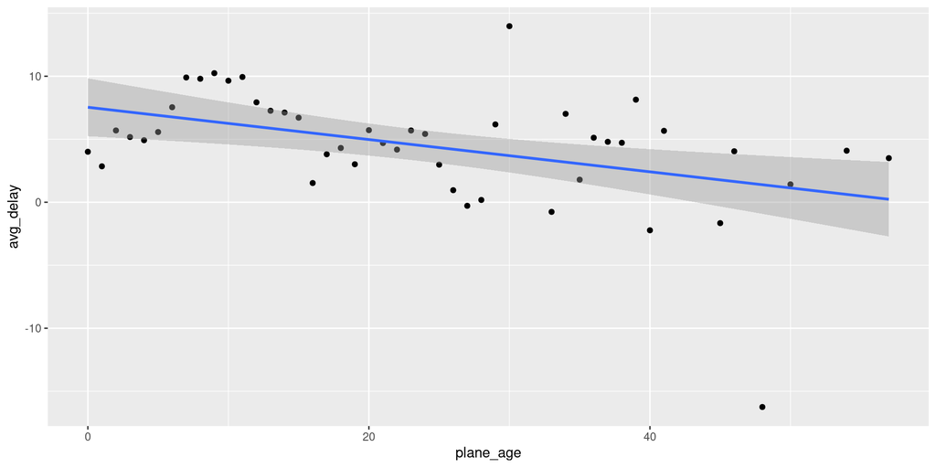

```r
plane_delays_age |>
  group_by(plane_age) |>
  summarise(avg_delay = mean(arr_delay)) |>
  ggplot(aes(x = plane_age, y = avg_delay)) +
  geom_point() +
  geom_smooth(method = "lm", formula = y ~ x)
```